# rapportV2

Analyse prédictive des prix de location Airbnb

1. Contexte du projet

   Dans un marché immobilier de plus en plus compétitif, comprendre les facteurs qui influencent le prix des locations à court terme est devenu essentiel tant pour les propriétaires que pour les plateformes comme Airbnb. Ce projet vise à analyser en profondeur un ensemble de données de propriétés Airbnb pour identifier les déterminants du prix et développer un modèle prédictif fiable.

   **Objectifs principaux :**
   - Comprendre les variables qui influencent significativement le prix des locations
   - Quantifier l'impact des différentes caractéristiques (localisation, type de propriété, aménités, etc.)
   - Développer un modèle capable de prédire avec précision le prix d'une location en fonction de ses attributs

   Cette analyse s'appuie sur un jeu de données contenant des informations détaillées sur 15 601 propriétés (22 235 originellement) Airbnb.
2. Description des données d'entrainement

#### 2.1 Source et structure des données

   Le jeu de données utilisé provient du projet d'Analyse de données d'année 3 ESILV semestre 2. Après nettoyage, nous disposons de 15 601 propriétés avec 21 variables pertinentes pour notre analyse prédictive.

   Ces variables peuvent être regroupées en plusieurs catégories fonctionnelles reflétant différents aspects des propriétés Airbnb :

##### Chiffres clés

   | Catégorie | Variables |
   | --- | --- |
   | **Identifiants** | id |
   | **Variable Cible** | log_price |
   | **Caractéristiques physiques** | property_type, room_type, accommodates, bedrooms, beds, bed_type, bathrooms, amenities |
   | **Localisation** | city, neighbourhood, latitude, longitude |
   | **Règles et politiques** | cancellation_policy, cleaning_fee, instant_bookable |
   | **Information sur l'hôte** | host_since, host_identity_verified |
   | **Réputation** | number_of_reviews, review_scores_rating |

#### 2.2 Nettoyage et prétraitement des données

##### Variables exclues

   Nous avons délibérément exclu certaines variables de notre analyse :
   - **description** : Influence potentiellement importante mais difficile à traiter efficacement
   - **first_review**, **host_has_profile_pic**, **host_response_rate**, **last_review**, **name**, **zipcode** : Impact limité sur notre objectif de prédiction

##### Étapes de nettoyage

   **Remarque méthodologique :** La transformation logarithmique du prix (log_price) constitue un prétraitement essentiel pour normaliser cette variable et améliorer les performances des modèles prédictifs, comme nous le verrons dans la section 4.1.
3. Méthodologie d'analyse

#### 3.1 Approche générale

   Notre méthodologie suit une approche progressive, permettant d'explorer les données en profondeur avant de développer notre modèle prédictif :

   1

   **Analyse exploratoire des données**

   Compréhension de la distribution des variables et identification des tendances générales

   2

   **Analyse bivariée**

   Examen des relations entre chaque variable explicative et le prix

   3

   **Analyse multivariée**

   Détection des interactions complexes entre variables

   4

   **Modélisation prédictive**

   Développement et évaluation de modèles quantitatifs

##### 3.2 Outils et techniques utilisés

###### Manipulation des données

- **Pandas** : Traitement et nettoyage des données
- **NumPy** : Calculs numériques avancés

###### Visualisation

- **Matplotlib** : Visualisations personnalisées
- **Seaborn** : Graphiques statistiques avancés

###### Modélisation

- **Scikit-learn** : Algorithmes de régression et métriques d'évaluation

4. Analyse exploratoire des données d'entrainement 4.1 Analyse de la distribution des prix

#### Comparaison des distributions : l'intérêt de la transformation logarithmique

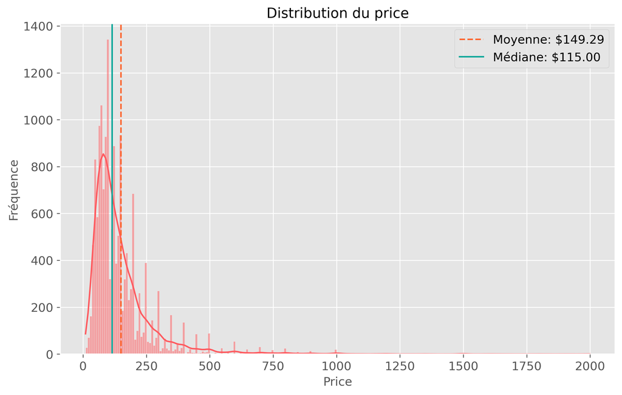

**Figure 1:** La distribution des prix bruts présente une **forte asymétrie positive** (coefficient de 4.02) avec une longue queue à droite, rendant difficile l'application de modèles paramétriques.

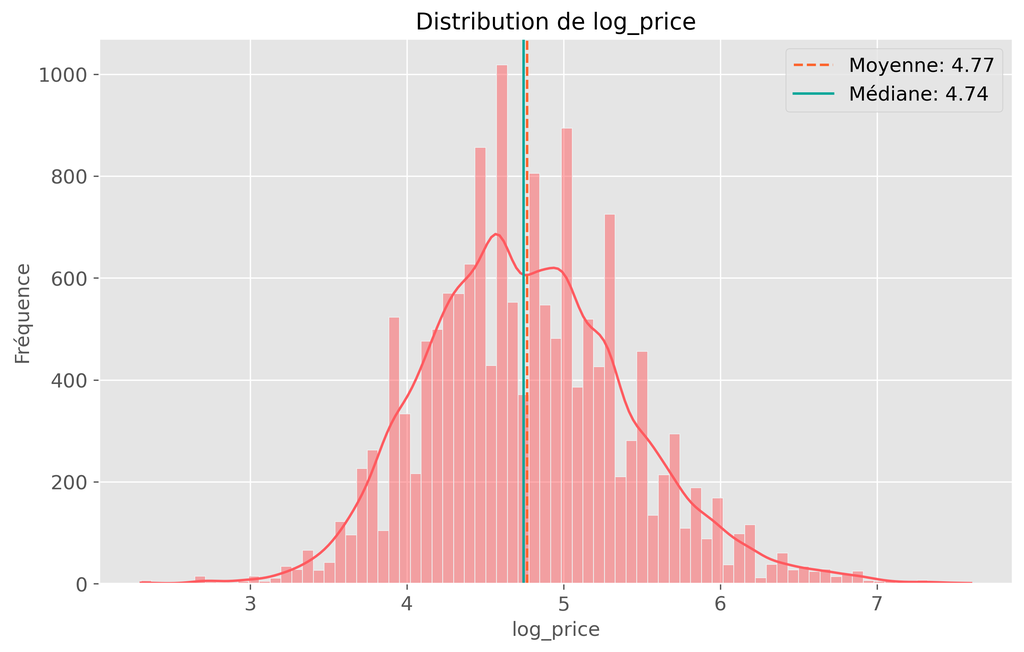

**Figure 2:** La transformation logarithmique produit une distribution **quasi-normale** (asymétrie réduite à 0.36), bien plus adaptée à la modélisation statistique.

#### Statistiques descriptives et observations clés

| Statistique | log_price | price ($) |
| --- | --- | --- |
| Moyenne | 4.7685 | 149.29 |
| Médiane | 4.7449 | 115.00 |
| Écart-type | 0.6586 | 130.96 |
| Minimum | 2.3026 | 10.00 |
| 25ème percentile | 4.3175 | 75.00 |
| 75ème percentile | 5.1874 | 179.00 |
| Maximum | 7.6004 | 1999.00 |
| Asymétrie | **0.3618** | **4.02** |
| Aplatissement | **0.4388** | **28.06** |

##### Distorsion des prix bruts

- Écart important entre moyenne ($149) et médiane ($115), confirmant l'asymétrie
- Aplatissement très élevé (28.06) indiquant de nombreuses valeurs extrêmes
- Rapport max/min de 200:1 (prix entre $10 et $1999)

##### Bénéfices de la transformation logarithmique

- Normalisation significative de la distribution (asymétrie réduite de 91%)
- Écart minimal entre moyenne et médiane (0.0236)
- Réduction drastique de l'aplatissement (de 28.06 à 0.44)
- Meilleure adéquation aux hypothèses des modèles paramétriques

#### Analyse de la normalité par QQ-Plots

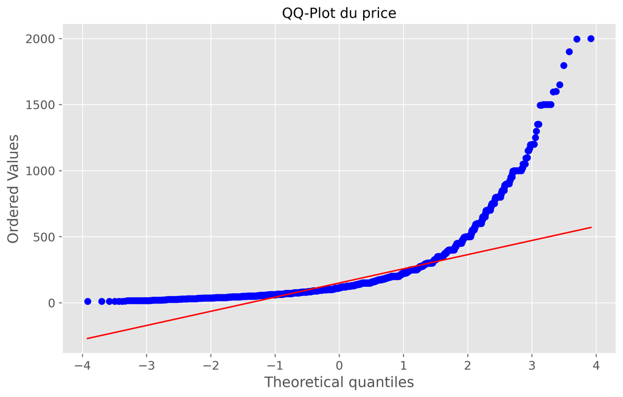

**Figure 3:** Le QQ-plot des prix bruts montre une **forte déviation** par rapport à la distribution normale théorique, particulièrement pour les valeurs élevées.

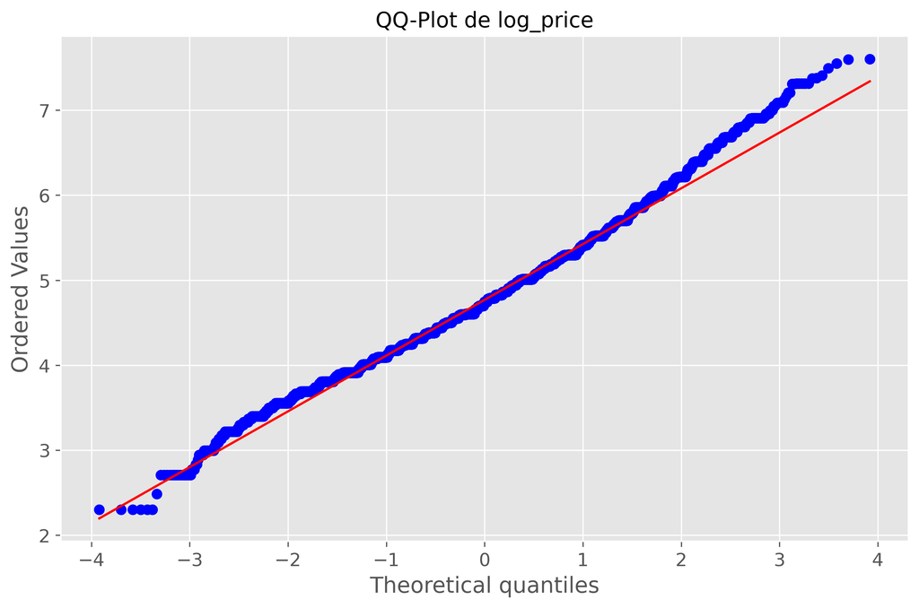

**Figure 4:** Le QQ-plot de log_price révèle une **bien meilleure adéquation** à la normalité, les points suivant plus fidèlement la ligne diagonale de référence.

#### Implications pour la modélisation

L'analyse de la distribution des prix nous conduit à plusieurs conclusions importantes pour notre approche de modélisation :

1. **Utilisation systématique de log_price** comme variable cible dans nos modèles prédictifs, en raison de ses propriétés statistiques nettement supérieures
2. **Meilleure adéquation aux techniques paramétriques** comme la régression linéaire, qui présupposent une distribution normale des résidus
3. **Interprétation plus intuitive des coefficients** en termes de variations relatives plutôt qu'absolues, permettant une meilleure généralisation à travers différentes gammes de prix
4. **Réduction de l'influence des valeurs aberrantes** sur les performances du modèle, grâce à la compression des extrémités de la distribution

Cette transformation logarithmique constitue donc une étape fondamentale du prétraitement de nos données, permettant d'améliorer significativement les performances et la robustesse de nos modèles prédictifs.

4.2 Analyse des caractéristiques physiques des propriétés

#### 4.2.1 Profil des hébergements et leur impact sur les prix

Cette section examine comment les attributs physiques des logements influencent leur prix sur Airbnb. Nous analysons d'abord les types de propriété, puis l'impact des aménités, avant de synthétiser ces relations dans une matrice de corrélation.

##### Types de propriétés : domination des appartements urbains

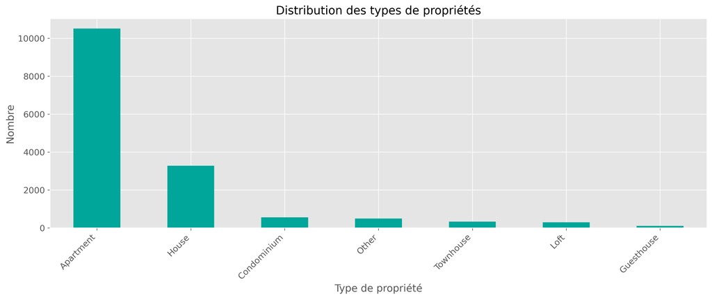

Les **appartements représentent 65%** des annonces Airbnb, suivis des maisons (21%), reflétant le caractère urbain du marché.

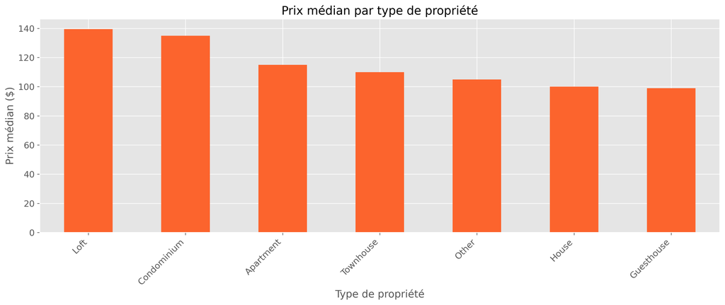

Les **lofts ($139) et condominiums ($133)** commandent les prix les plus élevés, incarnant le segment premium du marché.

##### Modes d'occupation : l'importance du logement entier

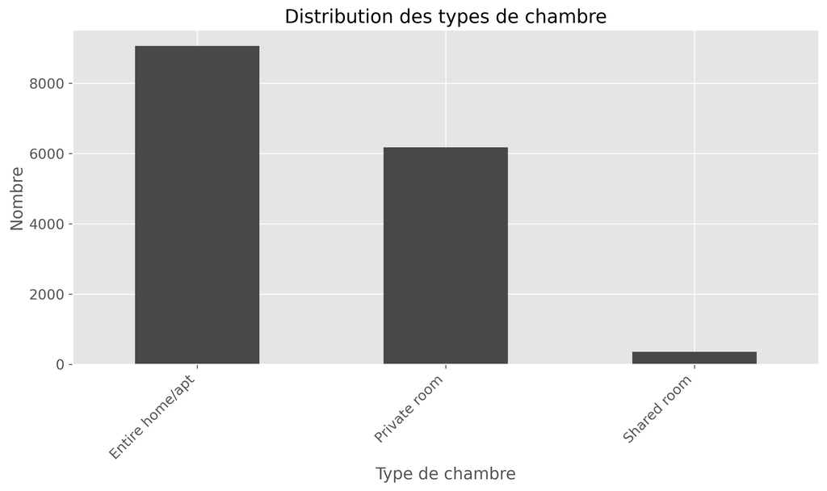

58% des annonces concernent des **logements entiers**, contre 39% pour les **chambres privées** et seulement 3% pour les **chambres partagées**.

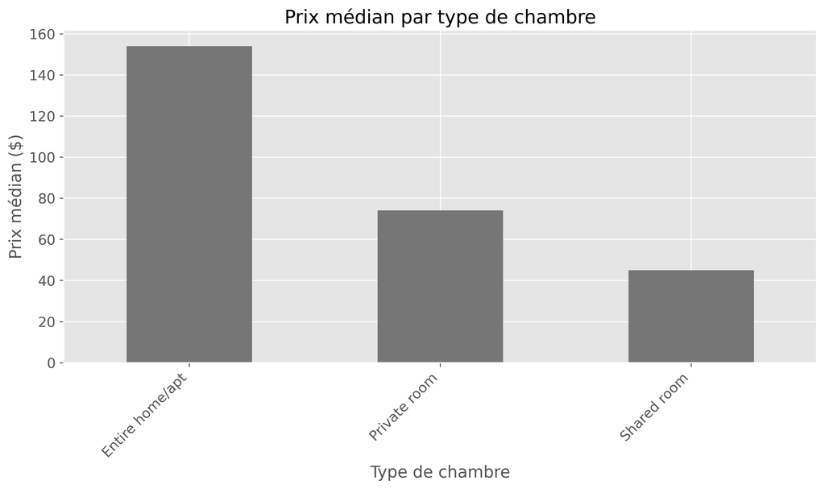

Les **logements entiers** sont près de **deux fois plus chers** ($153) que les chambres privées ($75), reflétant la prime pour l'intimité.

##### Types de lits : standardisation du marché

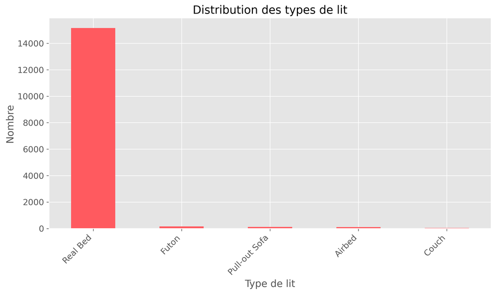

Les **lits standards dominent à 95%** du marché, les autres types étant marginaux et généralement associés à des logements de moindre standing.

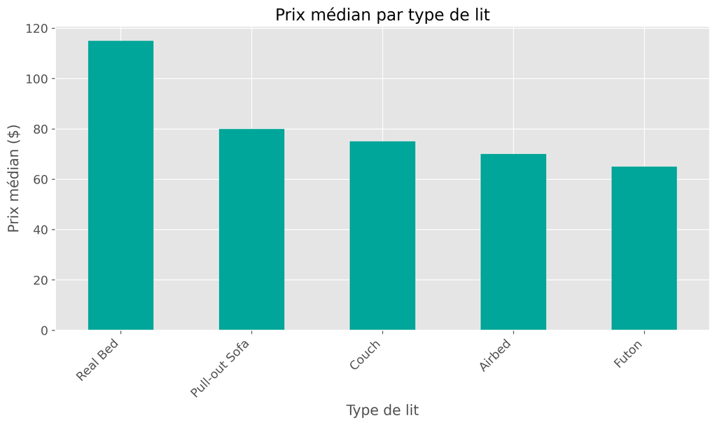

Le prix médian des logements avec **lits standards ($115)** est significativement plus élevé que ceux avec des lits alternatifs (canapés, futons).

Les caractéristiques physiques démontrent une polarisation du marché Airbnb entre les logements entiers premium (appartements et lofts avec lits standards) et les options économiques (chambres privées/partagées). Le type de logement et le mode d'occupation apparaissent comme des facteurs déterminants du prix.

#### 4.2.2 L'impact stratégique des aménités sur la valorisation

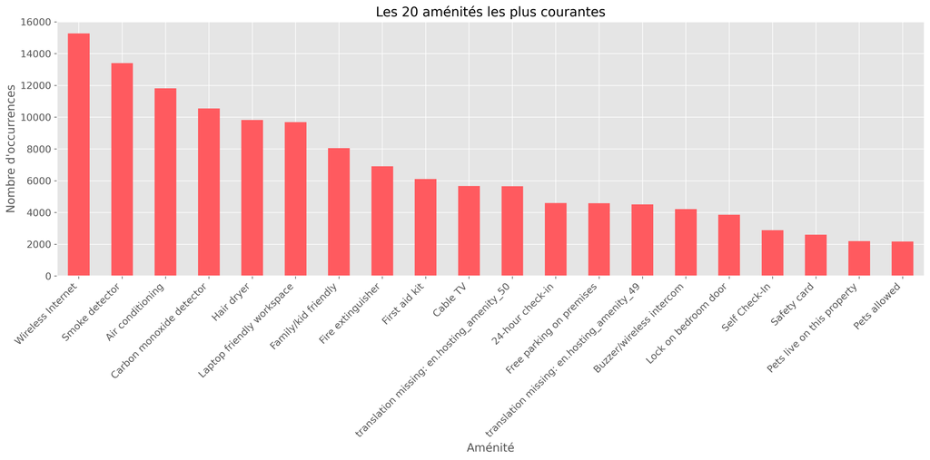

##### Des aménités premium à fort impact

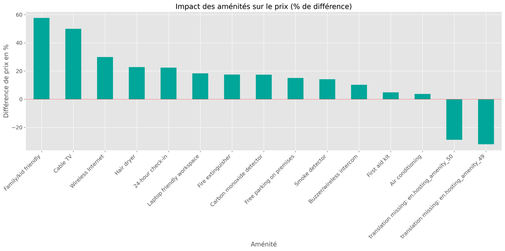

##### L'accumulation d'aménités premium: un puissant levier de prix

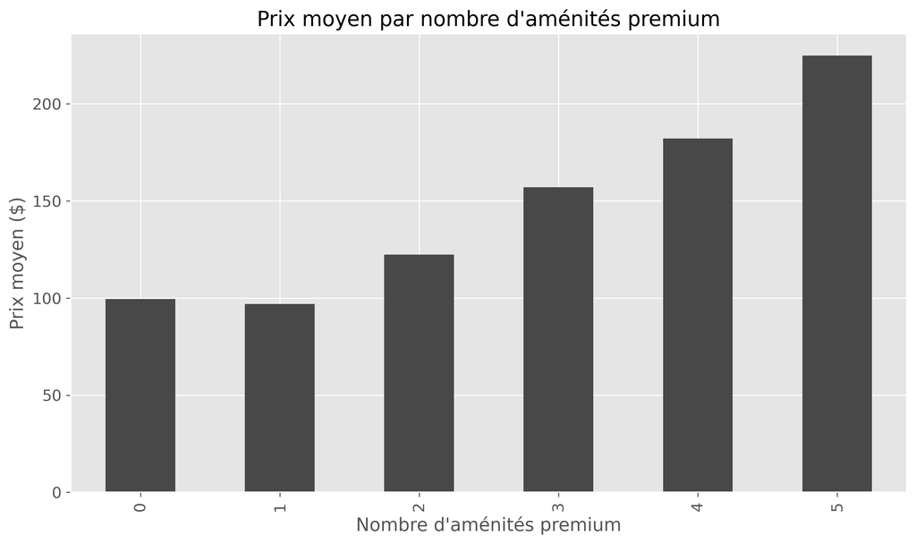

#### 4.2.3 Synthèse des corrélations et facteurs déterminants

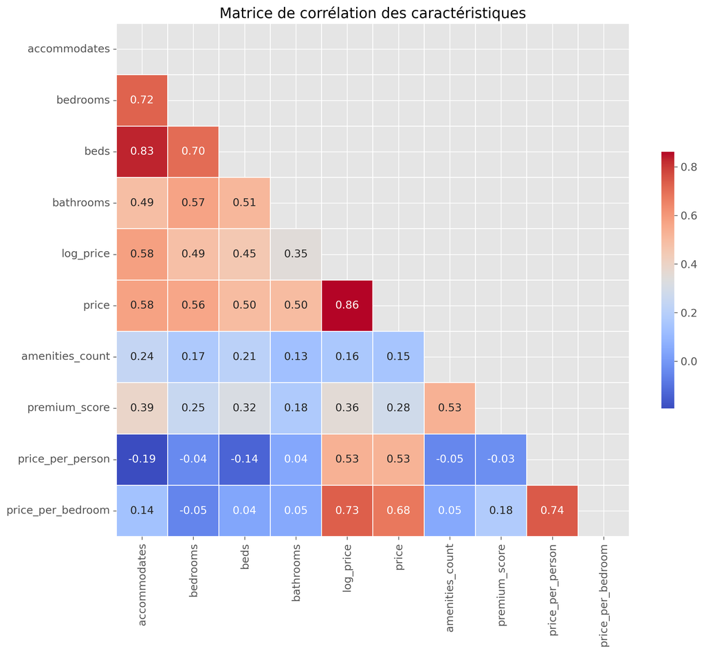

**Cluster aménités**: Le nombre d'aménités et le score premium sont modérément corrélés au prix (r = 0.16-0.36), mais leur impact combiné crée un effet multiplicateur significatif, particulièrement visible dans les segments supérieurs.

**Prix relatif**: Les mesures de prix par personne et par chambre présentent des corrélations distinctes, révélant des dynamiques de valorisation différentes selon le segment de marché.

##### Conclusion sur les déterminants physiques du prix

Ces facteurs constitueront les variables explicatives fondamentales dans notre modèle prédictif, permettant une estimation plus précise des prix selon les caractéristiques physiques des biens.

4.3 Analyse géographique et impact de la localisation

4.4 Analyse de l'influence des hôtes et des avis

[output not shown]

5. Modélisation prédictive

[output not shown]

[output not shown]

[output not shown]

6. Résultats et interprétation

#### 6.1 Facteurs déterminants du prix

[output not shown]

7. Conclusion et perspectives

[output not shown]

[output not shown]

8. Références

[output not shown]